[figure not shown]

# WORKSHOP: INTRODUCTION TO PYTHON FOR STATISTICAL ANALYSIS

- Arthur Marques (GAA)
- Mathurada Jullamon (GAA)
- Minjeong Park
- Mohammad Zubair

# Learning Goals

[figure not shown]

- Understand the basic commands of Python
- Learn how to load, preprocess, and explore datasets
- Learn the basic commands for descriptive statistics
- Learn basic commands for inference statistics

## Workshop materials & Setup

1. Access the UBC research commons Python Github page
2. Download the files for this workshop
3. Upload files to `syzygy` the files for this workshop
4. Create a new `Python 3` notebook

## Overview of quantitative research

[figure not shown]

# Basic Commands

[figure not shown]

### Tips and shortcuts

- `esc` goes to the command palette. While on command mode:
  - `A` to insert cell above
  - `B` to insert cell below
  - `M` to change cell to markdown
  - `D` + `D` to delete current cell
- `shift` + `enter` runs the code in the current cell

While typing a command press `tab` to have suggestions for **auto-completion**

### Importing libraries and dependencies

First and foremost, you should indicate that plotting results should be displayed as part of the notebook:

```python
# Matplotlib for additional plotting
from matplotlib import pyplot as plt
%matplotlib notebook
```

Then, we can import the several utilitary packages that help some of our coding procedures:

```python
import csv
import json
import pandas as pd # data processing, csv file I/O (e.g. pd.read_csv)
import numpy as np # linear algebra
from scipy import stats # statistics
from datetime import datetime # date time manipulation

#from IPython.core.interactiveshell import InteractiveShell # pretty display of variable can see the output of multiple statements at once
#InteractiveShell.ast_node_interactivity = "all"
```

## Basic Types

For a more detailed tutorial, pelase refer to the [Python documentation](https://docs.python.org/3/tutorial/index.html)

### Strings

Additional information available [here](https://docs.python.org/3/tutorial/introduction.html#strings)

[figure not shown]

```python
greetings = "Hello"
print(greetings)
```

```
Hello
```

```python
tutorial = "Python "
offered_by = "Research Commons"

print(tutorial + offered_by)
```

```
Python Research Commons
```

```python
offered_by[:8] # check substring
```

```
'Research'
```

```python
offered_by[:offered_by.index(" ")]  # we can get indexes programatically
```

```
'Research'
```

```python
"Research" in offered_by # check if some string contains another
```

```
True
```

```python
"RESEARCH" in offered_by
```

```
False
```

```python
"Research".upper() # convert to upper
```

```
'RESEARCH'
```

```python
"Research".lower() # convert to  lowercase
```

```
'research'
```

### Numbers

Additional information available [here](https://docs.python.org/3/tutorial/introduction.html#numbers)

```python
x = 2.
y = 4.
```

```python
x + y # sum
```

```
6.0
```

```python
y**x # power
```

```
16.0
```

```python
y / x # division
```

```
2.0
```

## Basic Data Structures

### Lists

Additional information available [here](https://docs.python.org/3/tutorial/introduction.html#lists) and also [here](https://docs.python.org/3/tutorial/datastructures.html#more-on-lists)

`brics = ["Brazil", "Russia", "India", "China", "South Africa"]`

| Brazil | Russia | India | China | South Africa |
| --- | --- | --- | --- | --- |
| 0 | 1 | 2 | 3 | 4 |

```python
brics = ["Brazil", "Russia", "India", "China", "South Africa"]
```

```python
brics[0]
```

```
'Brazil'
```

```python
brics[4]
```

```
'South Africa'
```

```python
brics[5] # error because the index is greater than the list
```

```
---------------------------------------------------------------------------
IndexError                                Traceback (most recent call last)
<ipython-input-18-09cd95e59f1a> in <module>
----> 1 brics[5] # error because the index is greater than the list

IndexError: list index out of range
```

```python
for country in brics:
    print("\tThis is a loop. I am iterating over the list. c =", country)
```

```
	This is a loop. I am iterating over the list. c = Brazil
	This is a loop. I am iterating over the list. c = Russia
	This is a loop. I am iterating over the list. c = India
	This is a loop. I am iterating over the list. c = China
	This is a loop. I am iterating over the list. c = South Africa
```

### Dictionary

Additional information available [here](https://docs.python.org/3/tutorial/datastructures.html#dictionaries)

```python
country_groups = {
    "brics": ["Brazil", "Russia", "India", "China", "South Africa"],
    "mercosur": [ "Argentina", "Brazil", "Paraguay", "Uruguay"],
    "last_update": 2019,
}
```

`key`: `values`

| brics | mercosur | last_update |
| --- | --- | --- |
| list | list | number |

```python
print(json.dumps(country_groups, indent=4, sort_keys=True))
```

```
{
    "brics": [
        "Brazil",
        "Russia",
        "India",
        "China",
        "South Africa"
    ],
    "last_update": 2019,
    "mercosur": [
        "Argentina",
        "Brazil",
        "Paraguay",
        "Uruguay"
    ]
}
```

```python
country_groups["brics"] # get values of key
```

```
['Brazil', 'Russia', 'India', 'China', 'South Africa']
```

```python
country_groups["last_update"]
```

```
2019
```

```python
country_groups["mercosur"]
```

```
['Argentina', 'Brazil', 'Paraguay', 'Uruguay']
```

```python
country_groups["test"] # error because we are trying to access a non existing key
```

```
---------------------------------------------------------------------------
KeyError                                  Traceback (most recent call last)
<ipython-input-25-297d10ab0729> in <module>
----> 1 country_groups["test"] # error because we are trying to access a non existing key

KeyError: 'test'
```

```python
country_groups["last_update"] = 2010 # updates value of key
country_groups["last_update"]
```

```
2010
```

```python
country_groups["mercosur"] += ["Chile"] # updates value of key adding a new element to the existing list
country_groups["mercosur"]
```

```
['Argentina', 'Brazil', 'Paraguay', 'Uruguay', 'Chile']
```

### Functions

It is not the focus of this workshop, but it may be useful to wrap some code around functions. You can read more about that [here](https://docs.python.org/3/tutorial/controlflow.html#defining-functions)

```python
def average_temperature(data):
    total = sum(data)
    return total / float(len(data))
```

```python
average_temperature([10, 20])
```

```
15.0
```

```python
average_temperature([10, 20, 30, 15])
```

```
18.75
```

```python
average_temperature([])
```

```
---------------------------------------------------------------------------
ZeroDivisionError                         Traceback (most recent call last)
<ipython-input-31-cedb8f17157e> in <module>
----> 1 average_temperature([])

<ipython-input-28-82db717bfa96> in average_temperature(data)
      1 def average_temperature(data):
      2     total = sum(data)
----> 3     return total / float(len(data))

ZeroDivisionError: float division by zero
```

# Exercise

1. Create a dictonary named `python_workshop`
2. Add the key `GAAs` with values `["Arthur", "Matty"]`
3. Add the key `location` with values `"UBC Library Research Commons"`
4. Add the key `attendants` with values `["Peter Pan", "Luke Skywalker", "Charlie Chaplin"]`
5. Write a loop to iterate over the `python_workshop` `attendants` printing only the first name of each attendant

> Tip: think how index(" ") may assist you in getting the first name

```python
# place holder for answer:
```

# Data Manipulation

[figure not shown]

#### Our data

[figure not shown]

For more details, check the [Pandas documentation](https://pandas.pydata.org/pandas-docs/stable/getting_started/10min.html#min)

### Load your data with the read_csv command

```python
mydata = pd.read_csv("GlobalLandTemperaturesByCountry.csv", error_bad_lines=False)
```

## Basic data commands

### columns: check variable names

```python
mydata.columns
```

```
Index(['dt', 'AverageTemperature', 'AverageTemperatureUncertainty', 'Country'], dtype='object')
```

### .head( ) look at first n lines of the table

```python
mydata.head() # only shows first few lines
```

|  | dt | AverageTemperature | AverageTemperatureUncertainty | Country |
| --- | --- | --- | --- | --- |
| 0 | 1743-11-01 | 4.384 | 2.294 | Åland |
| 1 | 1743-12-01 | NaN | NaN | Åland |
| 2 | 1744-01-01 | NaN | NaN | Åland |
| 3 | 1744-02-01 | NaN | NaN | Åland |
| 4 | 1744-03-01 | NaN | NaN | Åland |

### Select a single column

This work similarly to a dictionary where every `key` has a `list` of values of a certain type `dtype` (notice that `String` is of the type `object`)

```python
mydata['Country']
```

```
0            Åland
1            Åland
2            Åland
3            Åland
4            Åland
            ...
577457    Zimbabwe
577458    Zimbabwe
577459    Zimbabwe
577460    Zimbabwe
577461    Zimbabwe
Name: Country, Length: 577462, dtype: object
```

```python
mydata.Country
```

```
0            Åland
1            Åland
2            Åland
3            Åland
4            Åland
            ...
577457    Zimbabwe
577458    Zimbabwe
577459    Zimbabwe
577460    Zimbabwe
577461    Zimbabwe
Name: Country, Length: 577462, dtype: object
```

### Count values in column

- Useful later on for descriptive statistics

```python
mydata.Country.value_counts()
```

```
Romania                                3239
Guernsey                               3239
Bulgaria                               3239
Faroe Islands                          3239
Europe                                 3239
                                       ...
Northern Mariana Islands               1329
Guam                                   1329
French Southern And Antarctic Lands     788
Heard Island And Mcdonald Islands       788
Antarctica                              764
Name: Country, Length: 243, dtype: int64
```

## Basic data management commands

### check variable types

```python
mydata.dtypes
```

```
dt                                object
AverageTemperature               float64
AverageTemperatureUncertainty    float64
Country                           object
dtype: object
```

### Removing empty cells/rows

```python
mydata.dropna() # this operation creates a new dataframe. it does not change the existing one!
```

|  | dt | AverageTemperature | AverageTemperatureUncertainty | Country |
| --- | --- | --- | --- | --- |
| 0 | 1743-11-01 | 4.384 | 2.294 | Åland |
| 5 | 1744-04-01 | 1.530 | 4.680 | Åland |
| 6 | 1744-05-01 | 6.702 | 1.789 | Åland |
| 7 | 1744-06-01 | 11.609 | 1.577 | Åland |
| 8 | 1744-07-01 | 15.342 | 1.410 | Åland |
| 10 | 1744-09-01 | 11.702 | 1.517 | Åland |
| 11 | 1744-10-01 | 5.477 | 1.862 | Åland |
| 12 | 1744-11-01 | 3.407 | 1.425 | Åland |
| 13 | 1744-12-01 | -2.181 | 1.641 | Åland |
| 14 | 1745-01-01 | -3.850 | 1.841 | Åland |
| 15 | 1745-02-01 | -6.575 | 1.360 | Åland |
| 16 | 1745-03-01 | -4.195 | 1.213 | Åland |
| 17 | 1745-04-01 | -0.966 | 1.172 | Åland |
| 74 | 1750-01-01 | 1.091 | 1.119 | Åland |
| 75 | 1750-02-01 | 0.809 | 3.353 | Åland |
| 76 | 1750-03-01 | 0.923 | 4.716 | Åland |
| 77 | 1750-04-01 | 3.943 | 1.434 | Åland |
| 78 | 1750-05-01 | 6.265 | 1.339 | Åland |
| 79 | 1750-06-01 | 12.408 | 1.204 | Åland |
| 80 | 1750-07-01 | 16.683 | 1.184 | Åland |
| 81 | 1750-08-01 | 17.076 | 0.996 | Åland |
| 82 | 1750-09-01 | 11.459 | 1.881 | Åland |
| 83 | 1750-10-01 | 2.627 | 1.562 | Åland |
| 85 | 1750-12-01 | -4.058 | 2.166 | Åland |
| 86 | 1751-01-01 | -3.408 | 1.520 | Åland |
| 87 | 1751-02-01 | -8.393 | 2.525 | Åland |
| 88 | 1751-03-01 | -0.122 | 1.919 | Åland |
| 89 | 1751-04-01 | 2.159 | 0.922 | Åland |
| 91 | 1751-06-01 | 10.688 | 1.477 | Åland |
| 92 | 1751-07-01 | 15.660 | 0.966 | Åland |
| ... | ... | ... | ... | ... |
| 577431 | 2011-03-01 | 23.668 | 0.183 | Zimbabwe |
| 577432 | 2011-04-01 | 21.759 | 0.319 | Zimbabwe |
| 577433 | 2011-05-01 | 19.627 | 0.398 | Zimbabwe |
| 577434 | 2011-06-01 | 16.939 | 0.599 | Zimbabwe |
| 577435 | 2011-07-01 | 15.803 | 0.447 | Zimbabwe |
| 577436 | 2011-08-01 | 17.883 | 0.328 | Zimbabwe |
| 577437 | 2011-09-01 | 22.902 | 0.612 | Zimbabwe |
| 577438 | 2011-10-01 | 24.966 | 0.441 | Zimbabwe |
| 577439 | 2011-11-01 | 25.521 | 0.318 | Zimbabwe |
| 577440 | 2011-12-01 | 24.013 | 0.356 | Zimbabwe |
| 577441 | 2012-01-01 | 23.872 | 0.247 | Zimbabwe |
| 577442 | 2012-02-01 | 24.294 | 0.305 | Zimbabwe |
| 577443 | 2012-03-01 | 23.596 | 0.354 | Zimbabwe |
| 577444 | 2012-04-01 | 20.349 | 0.462 | Zimbabwe |
| 577445 | 2012-05-01 | 19.712 | 0.312 | Zimbabwe |
| 577446 | 2012-06-01 | 16.631 | 0.277 | Zimbabwe |
| 577447 | 2012-07-01 | 16.048 | 0.783 | Zimbabwe |
| 577448 | 2012-08-01 | 18.946 | 1.127 | Zimbabwe |
| 577449 | 2012-09-01 | 22.609 | 0.643 | Zimbabwe |
| 577450 | 2012-10-01 | 23.482 | 0.574 | Zimbabwe |
| 577451 | 2012-11-01 | 24.606 | 0.532 | Zimbabwe |
| 577452 | 2012-12-01 | 24.111 | 0.846 | Zimbabwe |
| 577453 | 2013-01-01 | 23.812 | 1.218 | Zimbabwe |
| 577454 | 2013-02-01 | 24.075 | 1.286 | Zimbabwe |
| 577455 | 2013-03-01 | 23.226 | 0.564 | Zimbabwe |
| 577456 | 2013-04-01 | 21.142 | 0.495 | Zimbabwe |
| 577457 | 2013-05-01 | 19.059 | 1.022 | Zimbabwe |
| 577458 | 2013-06-01 | 17.613 | 0.473 | Zimbabwe |
| 577459 | 2013-07-01 | 17.000 | 0.453 | Zimbabwe |
| 577460 | 2013-08-01 | 19.759 | 0.717 | Zimbabwe |

544811 rows × 4 columns

```python
mydata.head()
```

|  | dt | AverageTemperature | AverageTemperatureUncertainty | Country |
| --- | --- | --- | --- | --- |
| 0 | 1743-11-01 | 4.384 | 2.294 | Åland |
| 1 | 1743-12-01 | NaN | NaN | Åland |
| 2 | 1744-01-01 | NaN | NaN | Åland |
| 3 | 1744-02-01 | NaN | NaN | Åland |
| 4 | 1744-03-01 | NaN | NaN | Åland |

```python
mydata = mydata.dropna()
# now we are assigning the new dataframe to the same variable.
# We are overriding whathever mydata previously had in memory
mydata.head()
```

|  | dt | AverageTemperature | AverageTemperatureUncertainty | Country |
| --- | --- | --- | --- | --- |
| 0 | 1743-11-01 | 4.384 | 2.294 | Åland |
| 5 | 1744-04-01 | 1.530 | 4.680 | Åland |
| 6 | 1744-05-01 | 6.702 | 1.789 | Åland |
| 7 | 1744-06-01 | 11.609 | 1.577 | Åland |
| 8 | 1744-07-01 | 15.342 | 1.410 | Åland |

### select ( ): selects columns based on columns names

```python
mydata[['Country', 'dt']]
```

|  | Country | dt |
| --- | --- | --- |
| 0 | Åland | 1743-11-01 |
| 5 | Åland | 1744-04-01 |
| 6 | Åland | 1744-05-01 |
| 7 | Åland | 1744-06-01 |
| 8 | Åland | 1744-07-01 |
| 10 | Åland | 1744-09-01 |
| 11 | Åland | 1744-10-01 |
| 12 | Åland | 1744-11-01 |
| 13 | Åland | 1744-12-01 |
| 14 | Åland | 1745-01-01 |
| 15 | Åland | 1745-02-01 |
| 16 | Åland | 1745-03-01 |
| 17 | Åland | 1745-04-01 |
| 74 | Åland | 1750-01-01 |
| 75 | Åland | 1750-02-01 |
| 76 | Åland | 1750-03-01 |
| 77 | Åland | 1750-04-01 |
| 78 | Åland | 1750-05-01 |
| 79 | Åland | 1750-06-01 |
| 80 | Åland | 1750-07-01 |
| 81 | Åland | 1750-08-01 |
| 82 | Åland | 1750-09-01 |
| 83 | Åland | 1750-10-01 |
| 85 | Åland | 1750-12-01 |
| 86 | Åland | 1751-01-01 |
| 87 | Åland | 1751-02-01 |
| 88 | Åland | 1751-03-01 |
| 89 | Åland | 1751-04-01 |
| 91 | Åland | 1751-06-01 |
| 92 | Åland | 1751-07-01 |
| ... | ... | ... |
| 577431 | Zimbabwe | 2011-03-01 |
| 577432 | Zimbabwe | 2011-04-01 |
| 577433 | Zimbabwe | 2011-05-01 |
| 577434 | Zimbabwe | 2011-06-01 |
| 577435 | Zimbabwe | 2011-07-01 |
| 577436 | Zimbabwe | 2011-08-01 |
| 577437 | Zimbabwe | 2011-09-01 |
| 577438 | Zimbabwe | 2011-10-01 |
| 577439 | Zimbabwe | 2011-11-01 |
| 577440 | Zimbabwe | 2011-12-01 |
| 577441 | Zimbabwe | 2012-01-01 |
| 577442 | Zimbabwe | 2012-02-01 |
| 577443 | Zimbabwe | 2012-03-01 |
| 577444 | Zimbabwe | 2012-04-01 |
| 577445 | Zimbabwe | 2012-05-01 |
| 577446 | Zimbabwe | 2012-06-01 |
| 577447 | Zimbabwe | 2012-07-01 |
| 577448 | Zimbabwe | 2012-08-01 |
| 577449 | Zimbabwe | 2012-09-01 |
| 577450 | Zimbabwe | 2012-10-01 |
| 577451 | Zimbabwe | 2012-11-01 |
| 577452 | Zimbabwe | 2012-12-01 |
| 577453 | Zimbabwe | 2013-01-01 |
| 577454 | Zimbabwe | 2013-02-01 |
| 577455 | Zimbabwe | 2013-03-01 |
| 577456 | Zimbabwe | 2013-04-01 |
| 577457 | Zimbabwe | 2013-05-01 |
| 577458 | Zimbabwe | 2013-06-01 |
| 577459 | Zimbabwe | 2013-07-01 |
| 577460 | Zimbabwe | 2013-08-01 |

544811 rows × 2 columns

### filter dataframe based on conditions

```python
mydata[mydata['Country'] =="Canada"]
```

|  | dt | AverageTemperature | AverageTemperatureUncertainty | Country |
| --- | --- | --- | --- | --- |
| 97255 | 1768-09-01 | 5.257 | 3.107 | Canada |
| 97256 | 1768-10-01 | -3.393 | 2.981 | Canada |
| 97257 | 1768-11-01 | -12.829 | 3.967 | Canada |
| 97258 | 1768-12-01 | -20.582 | 4.622 | Canada |
| 97259 | 1769-01-01 | -24.756 | 4.722 | Canada |
| 97260 | 1769-02-01 | -22.915 | 2.871 | Canada |
| 97261 | 1769-03-01 | -16.862 | 3.359 | Canada |
| 97262 | 1769-04-01 | -5.292 | 3.154 | Canada |
| 97263 | 1769-05-01 | 4.857 | 4.409 | Canada |
| 97264 | 1769-06-01 | 11.971 | 2.941 | Canada |
| 97265 | 1769-07-01 | 13.953 | 2.945 | Canada |
| 97266 | 1769-08-01 | 11.621 | 3.643 | Canada |
| 97328 | 1774-10-01 | -2.952 | 3.325 | Canada |
| 97329 | 1774-11-01 | -13.403 | 4.644 | Canada |
| 97330 | 1774-12-01 | -22.913 | 3.041 | Canada |
| 97331 | 1775-01-01 | -20.603 | 3.117 | Canada |
| 97332 | 1775-02-01 | -18.234 | 3.481 | Canada |
| 97333 | 1775-03-01 | -12.975 | 2.656 | Canada |
| 97334 | 1775-04-01 | -7.375 | 2.573 | Canada |
| 97335 | 1775-05-01 | 2.417 | 3.026 | Canada |
| 97336 | 1775-06-01 | 8.523 | 3.983 | Canada |
| 97337 | 1775-07-01 | 12.797 | 2.343 | Canada |
| 97338 | 1775-08-01 | 11.340 | 2.618 | Canada |
| 97339 | 1775-09-01 | 4.166 | 2.431 | Canada |
| 97340 | 1775-10-01 | -1.683 | 2.847 | Canada |
| 97341 | 1775-11-01 | -7.536 | 4.663 | Canada |
| 97342 | 1775-12-01 | -21.367 | 2.857 | Canada |
| 97343 | 1776-01-01 | -26.035 | 5.275 | Canada |
| 97344 | 1776-02-01 | -20.605 | 3.711 | Canada |
| 97345 | 1776-03-01 | -17.101 | 2.712 | Canada |
| ... | ... | ... | ... | ... |
| 100166 | 2011-04-01 | -7.651 | 0.214 | Canada |
| 100167 | 2011-05-01 | 3.110 | 0.244 | Canada |
| 100168 | 2011-06-01 | 9.992 | 0.359 | Canada |
| 100169 | 2011-07-01 | 14.084 | 0.188 | Canada |
| 100170 | 2011-08-01 | 12.692 | 0.151 | Canada |
| 100171 | 2011-09-01 | 7.689 | 0.186 | Canada |
| 100172 | 2011-10-01 | -0.075 | 0.182 | Canada |
| 100173 | 2011-11-01 | -10.332 | 0.250 | Canada |
| 100174 | 2011-12-01 | -15.815 | 0.275 | Canada |
| 100175 | 2012-01-01 | -20.472 | 0.212 | Canada |
| 100176 | 2012-02-01 | -16.499 | 0.162 | Canada |
| 100177 | 2012-03-01 | -13.599 | 0.186 | Canada |
| 100178 | 2012-04-01 | -5.276 | 0.347 | Canada |
| 100179 | 2012-05-01 | 4.045 | 0.281 | Canada |
| 100180 | 2012-06-01 | 11.008 | 0.395 | Canada |
| 100181 | 2012-07-01 | 14.796 | 0.261 | Canada |
| 100182 | 2012-08-01 | 13.045 | 0.245 | Canada |
| 100183 | 2012-09-01 | 7.907 | 0.237 | Canada |
| 100184 | 2012-10-01 | -1.814 | 0.336 | Canada |
| 100185 | 2012-11-01 | -12.093 | 0.414 | Canada |
| 100186 | 2012-12-01 | -19.170 | 0.525 | Canada |
| 100187 | 2013-01-01 | -21.633 | 0.239 | Canada |
| 100188 | 2013-02-01 | -18.896 | 0.479 | Canada |
| 100189 | 2013-03-01 | -14.001 | 0.356 | Canada |
| 100190 | 2013-04-01 | -7.849 | 0.344 | Canada |
| 100191 | 2013-05-01 | 2.926 | 0.247 | Canada |
| 100192 | 2013-06-01 | 10.800 | 0.298 | Canada |
| 100193 | 2013-07-01 | 13.333 | 0.354 | Canada |
| 100194 | 2013-08-01 | 12.632 | 0.264 | Canada |
| 100195 | 2013-09-01 | 7.922 | 2.222 | Canada |

2504 rows × 4 columns

### filter may accept more than one condition

```python
mydata[(mydata['Country'] =="Canada") | (mydata['Country'] =="China")]
```

|  | dt | AverageTemperature | AverageTemperatureUncertainty | Country |
| --- | --- | --- | --- | --- |
| 97255 | 1768-09-01 | 5.257 | 3.107 | Canada |
| 97256 | 1768-10-01 | -3.393 | 2.981 | Canada |
| 97257 | 1768-11-01 | -12.829 | 3.967 | Canada |
| 97258 | 1768-12-01 | -20.582 | 4.622 | Canada |
| 97259 | 1769-01-01 | -24.756 | 4.722 | Canada |
| 97260 | 1769-02-01 | -22.915 | 2.871 | Canada |
| 97261 | 1769-03-01 | -16.862 | 3.359 | Canada |
| 97262 | 1769-04-01 | -5.292 | 3.154 | Canada |
| 97263 | 1769-05-01 | 4.857 | 4.409 | Canada |
| 97264 | 1769-06-01 | 11.971 | 2.941 | Canada |
| 97265 | 1769-07-01 | 13.953 | 2.945 | Canada |
| 97266 | 1769-08-01 | 11.621 | 3.643 | Canada |
| 97328 | 1774-10-01 | -2.952 | 3.325 | Canada |
| 97329 | 1774-11-01 | -13.403 | 4.644 | Canada |
| 97330 | 1774-12-01 | -22.913 | 3.041 | Canada |
| 97331 | 1775-01-01 | -20.603 | 3.117 | Canada |
| 97332 | 1775-02-01 | -18.234 | 3.481 | Canada |
| 97333 | 1775-03-01 | -12.975 | 2.656 | Canada |
| 97334 | 1775-04-01 | -7.375 | 2.573 | Canada |
| 97335 | 1775-05-01 | 2.417 | 3.026 | Canada |
| 97336 | 1775-06-01 | 8.523 | 3.983 | Canada |
| 97337 | 1775-07-01 | 12.797 | 2.343 | Canada |
| 97338 | 1775-08-01 | 11.340 | 2.618 | Canada |
| 97339 | 1775-09-01 | 4.166 | 2.431 | Canada |
| 97340 | 1775-10-01 | -1.683 | 2.847 | Canada |
| 97341 | 1775-11-01 | -7.536 | 4.663 | Canada |
| 97342 | 1775-12-01 | -21.367 | 2.857 | Canada |
| 97343 | 1776-01-01 | -26.035 | 5.275 | Canada |
| 97344 | 1776-02-01 | -20.605 | 3.711 | Canada |
| 97345 | 1776-03-01 | -17.101 | 2.712 | Canada |
| ... | ... | ... | ... | ... |
| 112436 | 2011-03-01 | 0.668 | 0.251 | China |
| 112437 | 2011-04-01 | 9.503 | 0.148 | China |
| 112438 | 2011-05-01 | 14.274 | 0.204 | China |
| 112439 | 2011-06-01 | 18.730 | 0.213 | China |
| 112440 | 2011-07-01 | 20.449 | 0.170 | China |
| 112441 | 2011-08-01 | 19.623 | 0.129 | China |
| 112442 | 2011-09-01 | 14.466 | 0.182 | China |
| 112443 | 2011-10-01 | 8.493 | 0.160 | China |
| 112444 | 2011-11-01 | 1.891 | 0.142 | China |
| 112445 | 2011-12-01 | -6.215 | 0.260 | China |
| 112446 | 2012-01-01 | -9.344 | 0.194 | China |
| 112447 | 2012-02-01 | -5.193 | 0.202 | China |
| 112448 | 2012-03-01 | 1.666 | 0.153 | China |
| 112449 | 2012-04-01 | 9.736 | 0.251 | China |
| 112450 | 2012-05-01 | 15.090 | 0.219 | China |
| 112451 | 2012-06-01 | 18.236 | 0.259 | China |
| 112452 | 2012-07-01 | 20.389 | 0.276 | China |
| 112453 | 2012-08-01 | 19.458 | 0.281 | China |
| 112454 | 2012-09-01 | 14.479 | 0.306 | China |
| 112455 | 2012-10-01 | 7.684 | 0.349 | China |
| 112456 | 2012-11-01 | -0.254 | 0.330 | China |
| 112457 | 2012-12-01 | -7.022 | 0.339 | China |
| 112458 | 2013-01-01 | -8.137 | 0.369 | China |
| 112459 | 2013-02-01 | -3.812 | 0.385 | China |
| 112460 | 2013-03-01 | 3.819 | 0.311 | China |
| 112461 | 2013-04-01 | 8.577 | 0.243 | China |
| 112462 | 2013-05-01 | 14.824 | 0.171 | China |
| 112463 | 2013-06-01 | 18.636 | 0.238 | China |
| 112464 | 2013-07-01 | 20.482 | 0.153 | China |
| 112465 | 2013-08-01 | 19.971 | 0.223 | China |

4705 rows × 4 columns

```python
# this may be useful for checking multiple conditions,
# e.g. filtering all countries in the Europe Union
country_list = ["China", "Canada"]
mydata[mydata['Country'].isin(country_list)]
```

|  | dt | AverageTemperature | AverageTemperatureUncertainty | Country |
| --- | --- | --- | --- | --- |
| 97255 | 1768-09-01 | 5.257 | 3.107 | Canada |
| 97256 | 1768-10-01 | -3.393 | 2.981 | Canada |
| 97257 | 1768-11-01 | -12.829 | 3.967 | Canada |
| 97258 | 1768-12-01 | -20.582 | 4.622 | Canada |
| 97259 | 1769-01-01 | -24.756 | 4.722 | Canada |
| 97260 | 1769-02-01 | -22.915 | 2.871 | Canada |
| 97261 | 1769-03-01 | -16.862 | 3.359 | Canada |
| 97262 | 1769-04-01 | -5.292 | 3.154 | Canada |
| 97263 | 1769-05-01 | 4.857 | 4.409 | Canada |
| 97264 | 1769-06-01 | 11.971 | 2.941 | Canada |
| 97265 | 1769-07-01 | 13.953 | 2.945 | Canada |
| 97266 | 1769-08-01 | 11.621 | 3.643 | Canada |
| 97328 | 1774-10-01 | -2.952 | 3.325 | Canada |
| 97329 | 1774-11-01 | -13.403 | 4.644 | Canada |
| 97330 | 1774-12-01 | -22.913 | 3.041 | Canada |
| 97331 | 1775-01-01 | -20.603 | 3.117 | Canada |
| 97332 | 1775-02-01 | -18.234 | 3.481 | Canada |
| 97333 | 1775-03-01 | -12.975 | 2.656 | Canada |
| 97334 | 1775-04-01 | -7.375 | 2.573 | Canada |
| 97335 | 1775-05-01 | 2.417 | 3.026 | Canada |
| 97336 | 1775-06-01 | 8.523 | 3.983 | Canada |
| 97337 | 1775-07-01 | 12.797 | 2.343 | Canada |
| 97338 | 1775-08-01 | 11.340 | 2.618 | Canada |
| 97339 | 1775-09-01 | 4.166 | 2.431 | Canada |
| 97340 | 1775-10-01 | -1.683 | 2.847 | Canada |
| 97341 | 1775-11-01 | -7.536 | 4.663 | Canada |
| 97342 | 1775-12-01 | -21.367 | 2.857 | Canada |
| 97343 | 1776-01-01 | -26.035 | 5.275 | Canada |
| 97344 | 1776-02-01 | -20.605 | 3.711 | Canada |
| 97345 | 1776-03-01 | -17.101 | 2.712 | Canada |
| ... | ... | ... | ... | ... |
| 112436 | 2011-03-01 | 0.668 | 0.251 | China |
| 112437 | 2011-04-01 | 9.503 | 0.148 | China |
| 112438 | 2011-05-01 | 14.274 | 0.204 | China |
| 112439 | 2011-06-01 | 18.730 | 0.213 | China |
| 112440 | 2011-07-01 | 20.449 | 0.170 | China |
| 112441 | 2011-08-01 | 19.623 | 0.129 | China |
| 112442 | 2011-09-01 | 14.466 | 0.182 | China |
| 112443 | 2011-10-01 | 8.493 | 0.160 | China |
| 112444 | 2011-11-01 | 1.891 | 0.142 | China |
| 112445 | 2011-12-01 | -6.215 | 0.260 | China |
| 112446 | 2012-01-01 | -9.344 | 0.194 | China |
| 112447 | 2012-02-01 | -5.193 | 0.202 | China |
| 112448 | 2012-03-01 | 1.666 | 0.153 | China |
| 112449 | 2012-04-01 | 9.736 | 0.251 | China |
| 112450 | 2012-05-01 | 15.090 | 0.219 | China |
| 112451 | 2012-06-01 | 18.236 | 0.259 | China |
| 112452 | 2012-07-01 | 20.389 | 0.276 | China |
| 112453 | 2012-08-01 | 19.458 | 0.281 | China |
| 112454 | 2012-09-01 | 14.479 | 0.306 | China |
| 112455 | 2012-10-01 | 7.684 | 0.349 | China |
| 112456 | 2012-11-01 | -0.254 | 0.330 | China |
| 112457 | 2012-12-01 | -7.022 | 0.339 | China |
| 112458 | 2013-01-01 | -8.137 | 0.369 | China |
| 112459 | 2013-02-01 | -3.812 | 0.385 | China |
| 112460 | 2013-03-01 | 3.819 | 0.311 | China |
| 112461 | 2013-04-01 | 8.577 | 0.243 | China |
| 112462 | 2013-05-01 | 14.824 | 0.171 | China |
| 112463 | 2013-06-01 | 18.636 | 0.238 | China |
| 112464 | 2013-07-01 | 20.482 | 0.153 | China |
| 112465 | 2013-08-01 | 19.971 | 0.223 | China |

4705 rows × 4 columns

```python
mydata[(mydata['Country'] =="Canada") & (mydata['AverageTemperature'] > 12)]
```

|  | dt | AverageTemperature | AverageTemperatureUncertainty | Country |
| --- | --- | --- | --- | --- |
| 97265 | 1769-07-01 | 13.953 | 2.945 | Canada |
| 97337 | 1775-07-01 | 12.797 | 2.343 | Canada |
| 97350 | 1776-08-01 | 12.487 | 3.137 | Canada |
| 97397 | 1780-07-01 | 14.635 | 2.816 | Canada |
| 97421 | 1782-07-01 | 12.307 | 4.053 | Canada |
| 97589 | 1796-07-01 | 12.637 | 3.010 | Canada |
| 97590 | 1796-08-01 | 12.812 | 3.293 | Canada |
| 97781 | 1812-07-01 | 12.611 | 2.498 | Canada |
| 97782 | 1812-08-01 | 12.740 | 3.179 | Canada |
| 97793 | 1813-07-01 | 13.311 | 2.363 | Canada |
| 97817 | 1815-07-01 | 14.117 | 2.489 | Canada |
| 97901 | 1822-07-01 | 12.809 | 2.750 | Canada |
| 97913 | 1823-07-01 | 12.832 | 2.711 | Canada |
| 97925 | 1824-07-01 | 14.296 | 2.365 | Canada |
| 97937 | 1825-07-01 | 13.078 | 3.139 | Canada |
| 97949 | 1826-07-01 | 12.726 | 2.789 | Canada |
| 97961 | 1827-07-01 | 12.917 | 2.353 | Canada |
| 97973 | 1828-07-01 | 13.316 | 2.379 | Canada |
| 97985 | 1829-07-01 | 12.551 | 2.065 | Canada |
| 97997 | 1830-07-01 | 13.673 | 2.554 | Canada |
| 98021 | 1832-07-01 | 12.247 | 3.183 | Canada |
| 98033 | 1833-07-01 | 12.122 | 2.301 | Canada |
| 98045 | 1834-07-01 | 12.462 | 2.379 | Canada |
| 98069 | 1836-07-01 | 12.091 | 2.362 | Canada |
| 98093 | 1838-07-01 | 12.679 | 3.320 | Canada |
| 98105 | 1839-07-01 | 12.669 | 3.016 | Canada |
| 98106 | 1839-08-01 | 12.056 | 2.368 | Canada |
| 98117 | 1840-07-01 | 13.690 | 1.780 | Canada |
| 98129 | 1841-07-01 | 12.699 | 1.941 | Canada |
| 98177 | 1845-07-01 | 12.093 | 1.985 | Canada |
| ... | ... | ... | ... | ... |
| 99965 | 1994-07-01 | 13.869 | 0.225 | Canada |
| 99977 | 1995-07-01 | 12.812 | 0.303 | Canada |
| 99989 | 1996-07-01 | 13.540 | 0.216 | Canada |
| 100001 | 1997-07-01 | 13.648 | 0.296 | Canada |
| 100013 | 1998-07-01 | 14.548 | 0.211 | Canada |
| 100014 | 1998-08-01 | 13.124 | 0.199 | Canada |
| 100025 | 1999-07-01 | 12.908 | 0.217 | Canada |
| 100026 | 1999-08-01 | 12.160 | 0.173 | Canada |
| 100037 | 2000-07-01 | 13.742 | 0.362 | Canada |
| 100049 | 2001-07-01 | 13.803 | 0.270 | Canada |
| 100050 | 2001-08-01 | 12.620 | 0.202 | Canada |
| 100061 | 2002-07-01 | 13.501 | 0.200 | Canada |
| 100073 | 2003-07-01 | 13.925 | 0.295 | Canada |
| 100074 | 2003-08-01 | 12.590 | 0.326 | Canada |
| 100085 | 2004-07-01 | 13.277 | 0.200 | Canada |
| 100097 | 2005-07-01 | 13.042 | 0.140 | Canada |
| 100109 | 2006-07-01 | 14.085 | 0.246 | Canada |
| 100110 | 2006-08-01 | 12.305 | 0.197 | Canada |
| 100121 | 2007-07-01 | 14.556 | 0.185 | Canada |
| 100133 | 2008-07-01 | 13.644 | 0.191 | Canada |
| 100134 | 2008-08-01 | 12.306 | 0.296 | Canada |
| 100145 | 2009-07-01 | 13.058 | 0.357 | Canada |
| 100157 | 2010-07-01 | 14.303 | 0.207 | Canada |
| 100158 | 2010-08-01 | 12.881 | 0.290 | Canada |
| 100169 | 2011-07-01 | 14.084 | 0.188 | Canada |
| 100170 | 2011-08-01 | 12.692 | 0.151 | Canada |
| 100181 | 2012-07-01 | 14.796 | 0.261 | Canada |
| 100182 | 2012-08-01 | 13.045 | 0.245 | Canada |
| 100193 | 2013-07-01 | 13.333 | 0.354 | Canada |
| 100194 | 2013-08-01 | 12.632 | 0.264 | Canada |

211 rows × 4 columns

### Wait this is starting to get really confusing!

- Try running this:

```python
mydata['Country'] == "Canada"
```

```
0         False
5         False
6         False
7         False
8         False
          ...
577456    False
577457    False
577458    False
577459    False
577460    False
Name: Country, Length: 544811, dtype: bool
```

### Let us take a step back and work with something simpler

```python
data = {
    'Name':['Tom', 'nick', 'krish', 'jack'],
    'Age':[20, 21, 19, 18]
}

df = pd.DataFrame(data)
```

```python
df
```

|  | Name | Age |
| --- | --- | --- |
| 0 | Tom | 20 |
| 1 | nick | 21 |
| 2 | krish | 19 |
| 3 | jack | 18 |

### Python data frame operates over lists, or arrays

```python
df[[True, False, True, True]]
```

|  | Name | Age |
| --- | --- | --- |
| 0 | Tom | 20 |
| 2 | krish | 19 |
| 3 | jack | 18 |

### When we do dataframe[ ] we are filtering one array according to the conditions in another array

```python
eg = df.Age >= 19
eg
```

```
0     True
1     True
2     True
3    False
Name: Age, dtype: bool
```

```python
df[eg]
```

|  | Name | Age |
| --- | --- | --- |
| 0 | Tom | 20 |
| 1 | nick | 21 |
| 2 | krish | 19 |

# `&` and `|` are `and` or `or` operations creating the eg list according to our desired conditions

```python
eg = (df.Age >= 19) & (df.Name == "Tom")
eg
df[eg]
```

|  | Name | Age |
| --- | --- | --- |
| 0 | Tom | 20 |

```python
eg = (df.Age >= 19) | (df.Name == "jack")
eg
df[eg]
```

|  | Name | Age |
| --- | --- | --- |
| 0 | Tom | 20 |
| 1 | nick | 21 |
| 2 | krish | 19 |
| 3 | jack | 18 |

## Adding new variables

#### Adding column representing the year

```python
mydata['year'] = mydata.apply(lambda row: datetime.strptime(row['dt'], '%Y-%m-%d').year, axis = 1)
```

**Whait? What?**

Command breakdown:

```python
datetime.strptime(mydata['dt'][0], '%Y-%m-%d') # converts a single element to a date
```

```
datetime.datetime(1743, 11, 1, 0, 0)
```

```python
datetime.strptime(mydata['dt'][0], '%Y-%m-%d').year # converts a single element to a date and get the year
```

```
1743
```

```python
## the command above is the same as in
row = mydata['dt'][0] # get 1st row
date = datetime.strptime(row, '%Y-%m-%d')
date.year
```

```
1743
```

Now that we now how to convert a single entry, let's do that for every element in our table

```python
# The lambda is like a loop. You can read it like:
# for every row in my data apply the datetime.strptime function ...
# ... which converts the element to a date and we extract the year of that date

# the [:100] is just to speed up the output.

mydata[:100].apply(lambda row: datetime.strptime(row['dt'], '%Y-%m-%d').year, axis = 1)
```

```
0      1743
5      1744
6      1744
7      1744
8      1744
       ...
167    1757
168    1757
169    1757
170    1758
171    1758
Length: 100, dtype: int64
```

```python
# Finally, we create a new column to store the data containing the year
mydata['year'] = mydata.apply(lambda row: datetime.strptime(row['dt'], '%Y-%m-%d').year, axis = 1)
```

```python
mydata.head()
```

|  | dt | AverageTemperature | AverageTemperatureUncertainty | Country | year |
| --- | --- | --- | --- | --- | --- |
| 0 | 1743-11-01 | 4.384 | 2.294 | Åland | 1743 |
| 5 | 1744-04-01 | 1.530 | 4.680 | Åland | 1744 |
| 6 | 1744-05-01 | 6.702 | 1.789 | Åland | 1744 |
| 7 | 1744-06-01 | 11.609 | 1.577 | Åland | 1744 |
| 8 | 1744-07-01 | 15.342 | 1.410 | Åland | 1744 |

#### Adding column representing the industrial era

```python
mydata['era'] = mydata.apply(lambda row: "gas & oil" if row['year'] <= 1969 else "electronic", axis = 1)
mydata.head()
```

|  | dt | AverageTemperature | AverageTemperatureUncertainty | Country | year | era |
| --- | --- | --- | --- | --- | --- | --- |
| 0 | 1743-11-01 | 4.384 | 2.294 | Åland | 1743 | gas & oil |
| 5 | 1744-04-01 | 1.530 | 4.680 | Åland | 1744 | gas & oil |
| 6 | 1744-05-01 | 6.702 | 1.789 | Åland | 1744 | gas & oil |
| 7 | 1744-06-01 | 11.609 | 1.577 | Åland | 1744 | gas & oil |
| 8 | 1744-07-01 | 15.342 | 1.410 | Åland | 1744 | gas & oil |

# Descriptive Statistics

[figure not shown]

### Descriptive stat with basic `describe` function

```python
mydata.describe()
```

|  | AverageTemperature | AverageTemperatureUncertainty | year |
| --- | --- | --- | --- |
| count | 544811.000000 | 544811.000000 | 544811.000000 |
| mean | 17.193354 | 1.019190 | 1913.145696 |
| std | 10.953966 | 1.202634 | 64.346358 |
| min | -37.658000 | 0.052000 | 1743.000000 |
| 25% | 10.025000 | 0.323000 | 1869.000000 |
| 50% | 20.901000 | 0.571000 | 1919.000000 |
| 75% | 25.814000 | 1.207000 | 1966.000000 |
| max | 38.842000 | 15.003000 | 2013.000000 |

### `unique` shows unique entries in a specific column

```python
mydata.Country.unique()
```

```
array(['Åland', 'Afghanistan', 'Africa', 'Albania', 'Algeria',
       'American Samoa', 'Andorra', 'Angola', 'Anguilla',
       'Antigua And Barbuda', 'Argentina', 'Armenia', 'Aruba', 'Asia',
       'Australia', 'Austria', 'Azerbaijan', 'Bahamas', 'Bahrain',
       'Baker Island', 'Bangladesh', 'Barbados', 'Belarus', 'Belgium',
       'Belize', 'Benin', 'Bhutan', 'Bolivia',
       'Bonaire, Saint Eustatius And Saba', 'Bosnia And Herzegovina',
       'Botswana', 'Brazil', 'British Virgin Islands', 'Bulgaria',
       'Burkina Faso', 'Burma', 'Burundi', "Côte D'Ivoire", 'Cambodia',
       'Cameroon', 'Canada', 'Cape Verde', 'Cayman Islands',
       'Central African Republic', 'Chad', 'Chile', 'China',
       'Christmas Island', 'Colombia', 'Comoros',
       'Congo (Democratic Republic Of The)', 'Congo', 'Costa Rica',
       'Croatia', 'Cuba', 'Curaçao', 'Cyprus', 'Czech Republic',
       'Denmark (Europe)', 'Denmark', 'Djibouti', 'Dominica',
       'Dominican Republic', 'Ecuador', 'Egypt', 'El Salvador',
       'Equatorial Guinea', 'Eritrea', 'Estonia', 'Ethiopia', 'Europe',
       'Falkland Islands (Islas Malvinas)', 'Faroe Islands',
       'Federated States Of Micronesia', 'Fiji', 'Finland',
       'France (Europe)', 'France', 'French Guiana', 'French Polynesia',
       'French Southern And Antarctic Lands', 'Gabon', 'Gambia',
       'Gaza Strip', 'Georgia', 'Germany', 'Ghana', 'Greece', 'Greenland',
       'Grenada', 'Guadeloupe', 'Guam', 'Guatemala', 'Guernsey',
       'Guinea Bissau', 'Guinea', 'Guyana', 'Haiti',
       'Heard Island And Mcdonald Islands', 'Honduras', 'Hong Kong',
       'Hungary', 'Iceland', 'India', 'Indonesia', 'Iran', 'Iraq',
       'Ireland', 'Isle Of Man', 'Israel', 'Italy', 'Jamaica', 'Japan',
       'Jersey', 'Jordan', 'Kazakhstan', 'Kenya', 'Kingman Reef',
       'Kiribati', 'Kuwait', 'Kyrgyzstan', 'Laos', 'Latvia', 'Lebanon',
       'Lesotho', 'Liberia', 'Libya', 'Liechtenstein', 'Lithuania',
       'Luxembourg', 'Macau', 'Macedonia', 'Madagascar', 'Malawi',
       'Malaysia', 'Mali', 'Malta', 'Martinique', 'Mauritania',
       'Mauritius', 'Mayotte', 'Mexico', 'Moldova', 'Monaco', 'Mongolia',
       'Montenegro', 'Montserrat', 'Morocco', 'Mozambique', 'Namibia',
       'Nepal', 'Netherlands (Europe)', 'Netherlands', 'New Caledonia',
       'New Zealand', 'Nicaragua', 'Niger', 'Nigeria', 'Niue',
       'North America', 'North Korea', 'Northern Mariana Islands',
       'Norway', 'Oceania', 'Oman', 'Pakistan', 'Palau', 'Palestina',
       'Palmyra Atoll', 'Panama', 'Papua New Guinea', 'Paraguay', 'Peru',
       'Philippines', 'Poland', 'Portugal', 'Puerto Rico', 'Qatar',
       'Reunion', 'Romania', 'Russia', 'Rwanda', 'Saint Barthélemy',
       'Saint Kitts And Nevis', 'Saint Lucia', 'Saint Martin',
       'Saint Pierre And Miquelon', 'Saint Vincent And The Grenadines',
       'Samoa', 'San Marino', 'Sao Tome And Principe', 'Saudi Arabia',
       'Senegal', 'Serbia', 'Seychelles', 'Sierra Leone', 'Singapore',
       'Sint Maarten', 'Slovakia', 'Slovenia', 'Solomon Islands',
       'Somalia', 'South Africa', 'South America',
       'South Georgia And The South Sandwich Isla', 'South Korea',
       'Spain', 'Sri Lanka', 'Sudan', 'Suriname',
       'Svalbard And Jan Mayen', 'Swaziland', 'Sweden', 'Switzerland',
       'Syria', 'Taiwan', 'Tajikistan', 'Tanzania', 'Thailand',
       'Timor Leste', 'Togo', 'Tonga', 'Trinidad And Tobago', 'Tunisia',
       'Turkey', 'Turkmenistan', 'Turks And Caicas Islands', 'Uganda',
       'Ukraine', 'United Arab Emirates', 'United Kingdom (Europe)',
       'United Kingdom', 'United States', 'Uruguay', 'Uzbekistan',
       'Venezuela', 'Vietnam', 'Virgin Islands', 'Western Sahara',
       'Yemen', 'Zambia', 'Zimbabwe'], dtype=object)
```

### `value_counts` shows number of entries per value. This is useful for categorical data

```python
mydata.Country.value_counts()
```

```
San Marino                             3166
Faroe Islands                          3166
France                                 3166
Montenegro                             3166
Guernsey                               3166
                                       ...
Federated States Of Micronesia         1364
Guam                                   1328
Northern Mariana Islands               1328
Heard Island And Mcdonald Islands       783
French Southern And Antarctic Lands     783
Name: Country, Length: 242, dtype: int64
```

```python
mydata.era.value_counts()
```

```
gas & oil     417982
electronic    126829
Name: era, dtype: int64
```

```python
mydata.year.value_counts()
```

```
1970    2904
1965    2904
1978    2904
1977    2904
1976    2904
        ...
1751     400
1744     400
1752     300
1745     200
1743      50
Name: year, Length: 267, dtype: int64
```

#### Sometimes, it may be useful to sort the output

```python
mydata.year.value_counts().sort_index()
```

```
1743      50
1744     400
1745     200
1750     550
1751     400
        ...
2009    2904
2010    2904
2011    2904
2012    2904
2013    1957
Name: year, Length: 267, dtype: int64
```

# Plotting with Seaborn

Seaborn is a lib that facilitates plotting data in Python. Check more [here](http://seaborn.pydata.org/tutorial.html) and also [here](https://elitedatascience.com/python-seaborn-tutorial)

```python
# Seaborn for plotting and styling
import seaborn as sns
```

### Create histogram for “year”

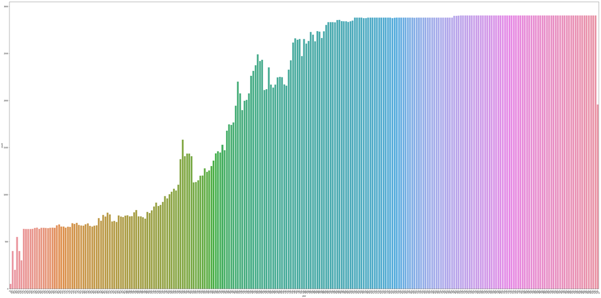

```python
# Count Plot (a.k.a. Bar Plot)
plt.xticks(rotation=-45)
plt.rcParams['figure.figsize'] = [60, 30]
sns.countplot(x='year', data=mydata)
```

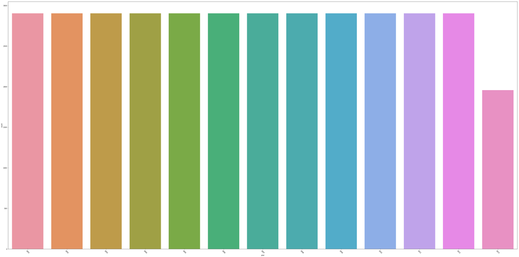

```python
# Count Plot (a.k.a. Bar Plot)
plt.xticks(rotation=-45)
plt.rcParams['figure.figsize'] = [60, 30]
sns.countplot(x='year', data=mydata[mydata['year'] > 2000])
```

[figure not shown]

I can't read a thing!

> We can change axes labels, size, orientation, and many other properties.

> Read more [here](https://matplotlib.org/api/pyplot_api.html#matplotlib.pyplot.legend) in the next examples, we change some properties to easy readability

#### Create histogram for “Era”

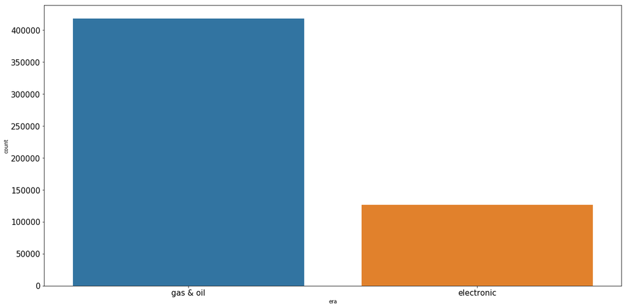

```python
plt.rcParams['figure.figsize'] = [20, 10]
plt.tick_params(axis='both', which='major', labelsize=15)
sns.countplot(x='era', data=mydata)
```

### Line graph of average temperature per year

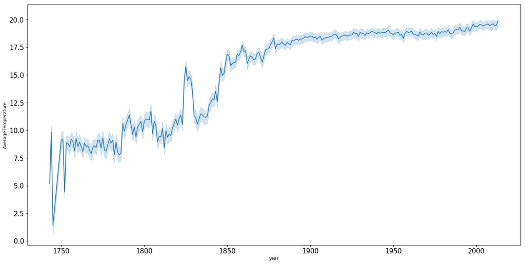

```python
plt.rcParams['figure.figsize'] = [20, 10]
plt.tick_params(axis='both', which='major', labelsize=15)
sns.lineplot(x="year", y="AverageTemperature", data=mydata)
```

# Exercise

## If we are on track, try to:

### 1. load carbon dioxide data per country

### 2. remove NA

### 3. Create a new column `CarbonDioxide` which has the same values as the column `Value`

### 4. view the data using the head( )

### Answer:

```python
carbon = pd.read_csv("carbonPerCountry.csv", error_bad_lines=False)
```

```python
carbon = carbon.dropna()
carbon['CarbonDioxide'] = carbon['Value']
carbon.head()
```

|  | Country | CountryCode | IndicatorName | IndicatorCode | year | Value | CarbonDioxide |
| --- | --- | --- | --- | --- | --- | --- | --- |
| 0 | Arab World | ARB | CO2 emissions (metric tons per capita) | EN.ATM.CO2E.PC | 1960 | 0.643964 | 0.643964 |
| 1 | Caribbean small states | CSS | CO2 emissions (metric tons per capita) | EN.ATM.CO2E.PC | 1960 | 1.402641 | 1.402641 |
| 2 | Central Europe and the Baltics | CEB | CO2 emissions (metric tons per capita) | EN.ATM.CO2E.PC | 1960 | 5.114244 | 5.114244 |
| 3 | East Asia & Pacific (all income levels) | EAS | CO2 emissions (metric tons per capita) | EN.ATM.CO2E.PC | 1960 | 1.162003 | 1.162003 |
| 4 | East Asia & Pacific (developing only) | EAP | CO2 emissions (metric tons per capita) | EN.ATM.CO2E.PC | 1960 | 0.952729 | 0.952729 |

# Inference Statistics

[figure not shown]

## Some housekeeping and background

### We are merging the tables by year!

```python
carbon_df = carbon.groupby(['year']).agg({'CarbonDioxide' : 'mean'})
carbon_df = carbon_df.reset_index()
temperature_df = mydata.groupby(['year']).agg({'AverageTemperature' : 'mean'})
temperature_df = temperature_df.reset_index()
new_data = pd.merge(temperature_df, carbon_df, on='year')
```

```python
new_data.head()
```

|  | year | AverageTemperature | CarbonDioxide |
| --- | --- | --- | --- |
| 0 | 1960 | 18.887013 | 2.158828 |
| 1 | 1961 | 18.923565 | 2.284448 |
| 2 | 1962 | 18.693847 | 2.393121 |
| 3 | 1963 | 18.675248 | 2.941375 |
| 4 | 1964 | 18.581275 | 3.092129 |

### Hypothesis testing

From [Wikipedia](https://en.wikipedia.org/wiki/Statistical_significance):

#### To determine whether a result is statistically significant, a researcher calculates a p-value, which is the probability of observing an effect of the same magnitude or more extreme given that the null hypothesis is true.

#### The null hypothesis is rejected if the p-value is less than a predetermined level, α.

#### α is called the significance level, and is the probability of rejecting the null hypothesis given that it is true (a type I error).

#### α is usually set at or below 5%.

[figure not shown]

## Our null hypotheses

### There is no difference in the Average temperature in the `gas & oil` era and the `electronic` era

```python
mydata.head()
```

|  | dt | AverageTemperature | AverageTemperatureUncertainty | Country | year | era |
| --- | --- | --- | --- | --- | --- | --- |
| 0 | 1743-11-01 | 4.384 | 2.294 | Åland | 1743 | gas & oil |
| 5 | 1744-04-01 | 1.530 | 4.680 | Åland | 1744 | gas & oil |
| 6 | 1744-05-01 | 6.702 | 1.789 | Åland | 1744 | gas & oil |
| 7 | 1744-06-01 | 11.609 | 1.577 | Åland | 1744 | gas & oil |
| 8 | 1744-07-01 | 15.342 | 1.410 | Åland | 1744 | gas & oil |

#### Independent T-test compares means between two groups

It is often used to see whether there is a group difference in continuous data **between two groups**

*Model assumptions*

```
(1) Independence

(2) Normality

(3) Equal variance
```

```python
group_a = mydata[mydata["era"] == "gas & oil"]["AverageTemperature"]
group_b = mydata[mydata["era"] == "electronic"]["AverageTemperature"]

stats.ttest_ind(group_a, group_b, equal_var = True)
```

```
Ttest_indResult(statistic=-72.11189394155966, pvalue=0.0)
```

Interpreting the results:

- `p-value < 0.0` pretty low, so that means that we can reject the null hypothesis
- Which one seems higher?

```python
print("gas & oil =", np.mean(group_a))
```

```
gas & oil = 16.60664427894024
```

```python
print("electronic =", np.mean(group_b))
```

```
electronic = 19.12693566928699
```

### Is there any association between the `AverageTemperature` and the `AverageCarbonEmission` ?

#### Pearson’s correlation is used to examine associations between variables (represented by continuous data) by looking at the direction and strength of the associations

```python
new_data.head()
```

|  | year | AverageTemperature | CarbonDioxide |
| --- | --- | --- | --- |
| 0 | 1960 | 18.887013 | 2.158828 |
| 1 | 1961 | 18.923565 | 2.284448 |
| 2 | 1962 | 18.693847 | 2.393121 |
| 3 | 1963 | 18.675248 | 2.941375 |
| 4 | 1964 | 18.581275 | 3.092129 |

```python
corr, pvalue = stats.pearsonr(new_data['AverageTemperature'], new_data['CarbonDioxide'])
```

### Interpreting the results:

```python
print("p-value=", pvalue)
```

```
p-value= 0.00018275663482094335
```

that means that there is statistically significant correlation between `temperature` and `carbon emission`

#### How strong is the correlation?

```python
print("corr = ", corr)
```

```
corr =  0.49628392520615205
```

`cor` varies from `-1` to `1` positive values indicate that an increase in the `y` variable increases the `x` variable by `corr`.

# Exercise

## If we are on track, try to:

### 1. compare the average temperature of the United States and Canada. Is this a fair comparison?

### 2. Create a data frame filtering `mydata`. The data frame must contain only countries in the `G20` list declared below

### 3. Merge `carbon` and the data frame created on `2` using `country` and also `year`

### 4. check the documentation of [elite data science](https://elitedatascience.com/python-seaborn-tutorial) and make a boxplot using the data frame created on `3` the boxplot should be `x`=Country and `y`= CarbonDioxide

```python
G20 = [
    "Argentina", "Australia", "Brazil", "Canada",
    "China", "Germany", "France", "India", "Indonesia", "Italy",
    "Japan", "Mexico", "Russia", "Saudi Arabia", "South Africa",
    "South Korea", "Turkey", "United Kingdom", "United States"
]
```

## Don't spoil the fun. The stick figure is watching you

[figure not shown]

### Answer:

```python
group_a = mydata[mydata["Country"] == "Canada"]["AverageTemperature"]
group_b = mydata[mydata["Country"] == "United States"]["AverageTemperature"]

stats.ttest_ind(group_a, group_b, equal_var = True)
print("Canada =", np.mean(group_a))
print("United States =", np.mean(group_b))
```

```
Canada = -5.216658945686901
United States = 8.60357252215955
```

```python
mydata.head()
```

|  | dt | AverageTemperature | AverageTemperatureUncertainty | Country | year | era |
| --- | --- | --- | --- | --- | --- | --- |
| 0 | 1743-11-01 | 4.384 | 2.294 | Åland | 1743 | gas & oil |
| 5 | 1744-04-01 | 1.530 | 4.680 | Åland | 1744 | gas & oil |
| 6 | 1744-05-01 | 6.702 | 1.789 | Åland | 1744 | gas & oil |
| 7 | 1744-06-01 | 11.609 | 1.577 | Åland | 1744 | gas & oil |
| 8 | 1744-07-01 | 15.342 | 1.410 | Åland | 1744 | gas & oil |

```python
g20_df = mydata[mydata["Country"].isin(G20)]
```

```python
# get carbon dioxide emission grouping by year and Country
carbon_df = carbon.groupby(['year', 'Country']).agg({'CarbonDioxide' : 'mean'})
carbon_df.reset_index()

# get average temperature grouping by year and Country
temperature_df = g20_df.groupby(['year', 'Country']).agg({'AverageTemperature' : 'mean'})
temperature_df.reset_index()

# merge dataframes
final_df = pd.merge(temperature_df, carbon_df, on=['year', 'Country']).dropna()
final_df = final_df.reset_index()

final_df.head()
```

|  | year | Country | AverageTemperature | CarbonDioxide |
| --- | --- | --- | --- | --- |
| 0 | 1960 | Argentina | 14.993667 | 2.367473 |
| 1 | 1960 | Australia | 21.210500 | 8.582937 |
| 2 | 1960 | Brazil | 24.752667 | 0.647068 |
| 3 | 1960 | Canada | -4.406833 | 10.770847 |
| 4 | 1960 | China | 6.890917 | 1.170381 |

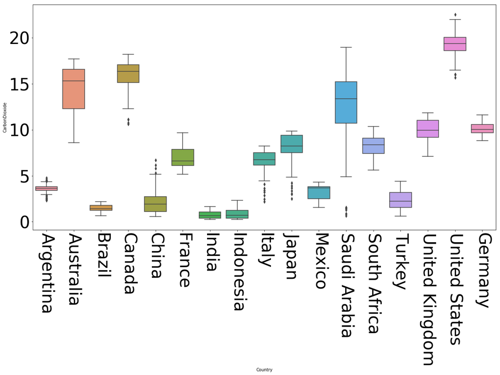

```python
plt.xticks(rotation=-90)
plt.rcParams['figure.figsize'] = [60, 30]
plt.tick_params(axis='both', which='major', labelsize=40)
sns.boxplot(x="Country", y="CarbonDioxide", data=final_df)
```

### Conclusions from our analysis

[figure not shown]

# Research Commons: An interdisciplinary research-driven learning environment

### * Literature review

### * Systematic Review Search Methodology

### * Citation Management

### * Thesis Formatting

### * Nvivo Software Support

### * SPSS Software Support

[figure not shown]

### * R Group

### * Multi-Disciplinary Graduate Student Writing Group

[figure not shown]

# Feedback

## http://bit.ly/RCfeedbackwinter2018